# California Housing Prices

Diego Alejandro Mernies

Primer cuatrimestre 2019

# Introducción

Realizaremos una análisis de los datos de las viviendas que se encuentran en un distrito determinado de **California** y algunas estadísticas basadas en el censo de **1990**.

## Objetivo.

Predecir el precio de las casa de la época con un modelo de regresión lineal. El problema es de aprendizaje supervisado.

En primer lugar cargamos las librerías requeridas. Si no las tiene en su sistema, puede instalarlas con `install.packages("librería")`.

```r
library(readr)
library(dplyr)
library(corrplot)
library(ggplot2)
library(scales)
library(rms)
```

## Definición de contantes

A continuación se define las **constantes** que se utilizarán en el proyecto.

```r
# URL donde reside el dataset a utilizar
dataurl <- "https://raw.githubusercontent.com/dmerniestic1987/tp_ciencia_datos_california_housing/master/input/housing.csv"
# Ubicación local en donde se guardará el dataset para su procesamiento
datadir <- "~/workspace/R/data"
```

# Carga de datos

## Set de datos

El set de datos es un archivo .csv (comma separated value) de exactamente 10 columnas y 20641 filas de las cuales la primera contiene los nombres. El archivo de input original se llama **housing.csv** y se tomó de [California Housing Price] (https://www.kaggle.com/camnugent/california-housing-prices), pero fue subido a un repositorio GIT para simplificar la descarga de los datos y controlar las versiones. El repositorio GIT se puede explorar ingresando a: https://github.com/dmerniestic1987/tp_ciencia_datos_california_housing.

Los datos pertenecen a las casas que se encuentran en un distrito de California y algunas estadísticas basadas en los datos del censo de 1990. Las variables son:

| Variable | Descripción |
| --- | --- |
| longitude | Qué tan lejos al oeste este está una casa. Un valor más alto está más al oeste. |
| latitude | Qué tan lejos al norte está una casa. Un valor más alto está más al norte. |
| housing_median_age | Edad media de una casa dentro de un bloque de casas. Un número más bajo es un edificio más nuevo. |
| total_rooms | Número total de ambientes dentro de un bloque de casas. |
| total_bedrooms | Número total de habitaciones dentro de un bloque de casas. |
| population | Número total de personas que residen dentro de un bloque de casas. |
| households | Número total de hogares, un grupo de personas que residen dentro de una unidad de hogar, por un bloque. |
| median_income | Ingreso promedio para hogares dentro de un bloque de casas (medido en decenas de miles de dólares estadounidenses) |
| median_house_value | Valor medio de la vivienda para hogares dentro de un bloque (medido en dólares estadounidenses) |
| ocean_proximity | Ubicación de la casa con relación al oceano o mar. |

```r
datafile <- paste(datadir, "housing.csv", sep = "/")
```

En primer lugar se verifica si es necesario crear un directorio para almacenar el archivo.

```r
if (dir.exists(datadir)) {
  print(paste("El directorio ", datadir, " ya existe."))
} else {
  print(paste("Creando directorio de datos", datadir, "."))
  dir.create(datadir)
}
```

```
[1] "El directorio  ~/workspace/R/data  ya existe."
```

El segundo lugar se descarga la última versión del archivo para poder utilizar la información actualizada.

```r
if (file.exists(datafile)) {
  print(paste("El archivo ", datafile, " ya existe, lo elimino."))
  file.remove(datafile)
}
```

```
[1] "El archivo  ~/workspace/R/data/housing.csv  ya existe, lo elimino."
[1] TRUE
```

```r
download.file(dataurl, datafile, method="auto")
```

```
probando la URL 'https://raw.githubusercontent.com/dmerniestic1987/tp_ciencia_datos_california_housing/master/input/housing.csv'
==================================================
```

## Lectura de los datos

Leemos el archivo recientemente descargado convirtiendo los espacios vacíos en N/A. Las columnas sin información no necesitan ser eliminadas dado que el resto de la información del futbolista puede ser útil.

```r
  dfhousing <- read.csv(datafile)
```

## Control de datos

Verifcamos que los nombres de las columnas sean correctos.

```r
colnames(dfhousing)
```

```
 [1] "longitude"          "latitude"           "housing_median_age" "total_rooms"        "total_bedrooms"
 [6] "population"         "households"         "median_income"      "median_house_value" "ocean_proximity"
```

Verificamos la dimensión y los tipos de datos de las columnas.

```r
dim(dfhousing)
```

```
[1] 20640    10
```

```r
str(dfhousing)
```

```
'data.frame':   20640 obs. of  10 variables:
 $ longitude         : num  -122 -122 -122 -122 -122 ...
 $ latitude          : num  37.9 37.9 37.9 37.9 37.9 ...
 $ housing_median_age: num  41 21 52 52 52 52 52 52 42 52 ...
 $ total_rooms       : num  880 7099 1467 1274 1627 ...
 $ total_bedrooms    : num  129 1106 190 235 280 ...
 $ population        : num  322 2401 496 558 565 ...
 $ households        : num  126 1138 177 219 259 ...
 $ median_income     : num  8.33 8.3 7.26 5.64 3.85 ...
 $ median_house_value: num  452600 358500 352100 341300 342200 ...
 $ ocean_proximity   : Factor w/ 5 levels "<1H OCEAN","INLAND",..: 4 4 4 4 4 4 4 4 4 4 ...
```

Verificamos el contenido de los primeros y últimos registros del archivo.

```r
head(dfhousing, give.attr=FALSE)
```

|  | longitude | latitude | housing_median_age | total_rooms | total_bedrooms | population | households | median_income | median_house_value | ocean_proximity |
| --- | --- | --- | --- | --- | --- | --- | --- | --- | --- | --- |
| 1 | -122.23 | 37.88 | 41 | 880 | 129 | 322 | 126 | 8.3252 | 452600 | NEAR BAY |
| 2 | -122.22 | 37.86 | 21 | 7099 | 1106 | 2401 | 1138 | 8.3014 | 358500 | NEAR BAY |
| 3 | -122.24 | 37.85 | 52 | 1467 | 190 | 496 | 177 | 7.2574 | 352100 | NEAR BAY |
| 4 | -122.25 | 37.85 | 52 | 1274 | 235 | 558 | 219 | 5.6431 | 341300 | NEAR BAY |
| 5 | -122.25 | 37.85 | 52 | 1627 | 280 | 565 | 259 | 3.8462 | 342200 | NEAR BAY |
| 6 | -122.25 | 37.85 | 52 | 919 | 213 | 413 | 193 | 4.0368 | 269700 | NEAR BAY |

```r
tail(dfhousing, give.attr=FALSE)
```

|  | longitude | latitude | housing_median_age | total_rooms | total_bedrooms | population | households | median_income | median_house_value | ocean_proximity |
| --- | --- | --- | --- | --- | --- | --- | --- | --- | --- | --- |
| 20635 | -121.56 | 39.27 | 28 | 2332 | 395 | 1041 | 344 | 3.7125 | 116800 | INLAND |
| 20636 | -121.09 | 39.48 | 25 | 1665 | 374 | 845 | 330 | 1.5603 | 78100 | INLAND |
| 20637 | -121.21 | 39.49 | 18 | 697 | 150 | 356 | 114 | 2.5568 | 77100 | INLAND |
| 20638 | -121.22 | 39.43 | 17 | 2254 | 485 | 1007 | 433 | 1.7000 | 92300 | INLAND |
| 20639 | -121.32 | 39.43 | 18 | 1860 | 409 | 741 | 349 | 1.8672 | 84700 | INLAND |
| 20640 | -121.24 | 39.37 | 16 | 2785 | 616 | 1387 | 530 | 2.3886 | 89400 | INLAND |

Obtenemos un resumen de las variables para verificar los datos.

```r
summary(dfhousing)
```

```
   longitude         latitude     housing_median_age  total_rooms    total_bedrooms     population
 Min.   :-124.3   Min.   :32.54   Min.   : 1.00      Min.   :    2   Min.   :   1.0   Min.   :    3
 1st Qu.:-121.8   1st Qu.:33.93   1st Qu.:18.00      1st Qu.: 1448   1st Qu.: 296.0   1st Qu.:  787
 Median :-118.5   Median :34.26   Median :29.00      Median : 2127   Median : 435.0   Median : 1166
 Mean   :-119.6   Mean   :35.63   Mean   :28.64      Mean   : 2636   Mean   : 537.9   Mean   : 1425
 3rd Qu.:-118.0   3rd Qu.:37.71   3rd Qu.:37.00      3rd Qu.: 3148   3rd Qu.: 647.0   3rd Qu.: 1725
 Max.   :-114.3   Max.   :41.95   Max.   :52.00      Max.   :39320   Max.   :6445.0   Max.   :35682
                                                                     NA's   :207
   households     median_income     median_house_value   ocean_proximity
 Min.   :   1.0   Min.   : 0.4999   Min.   : 14999     <1H OCEAN :9136
 1st Qu.: 280.0   1st Qu.: 2.5634   1st Qu.:119600     INLAND    :6551
 Median : 409.0   Median : 3.5348   Median :179700     ISLAND    :   5
 Mean   : 499.5   Mean   : 3.8707   Mean   :206856     NEAR BAY  :2290
 3rd Qu.: 605.0   3rd Qu.: 4.7432   3rd Qu.:264725     NEAR OCEAN:2658
 Max.   :6082.0   Max.   :15.0001   Max.   :500001
```

Del resumen estadísticos se detectó: * Es necesario limpiar los NA’S de la columna total_bedrooms. * Existen sólo 5 casas que están en una Isla. * Los valores máximos de total_rooms, total_bedrooms, population y households son muy altos en comparación a la media.

## Visualización de datos

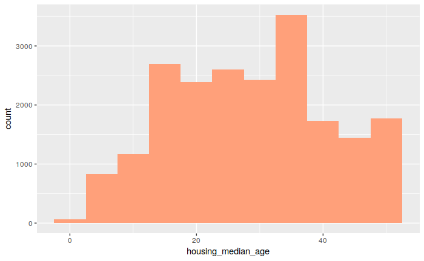

```r
ggplot(dfhousing) +
  geom_histogram(aes(x=housing_median_age), binwidth=5, fill="lightsalmon", bins=30)
```

Observamos que en el comunto de datos las casas tenían entre 1 y 52 años de antigüedad.

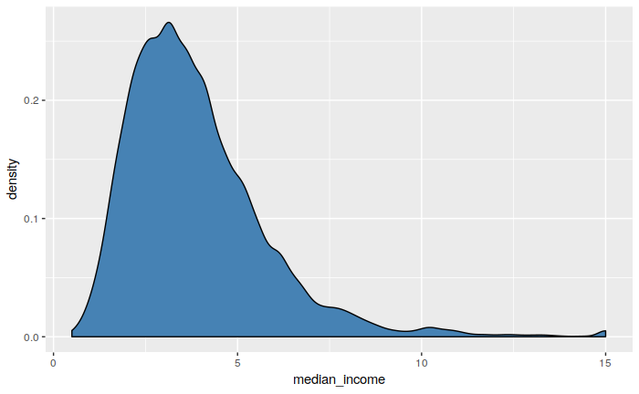

```r
ggplot(dfhousing) +
  geom_density(aes(x=median_income), fill="steel blue")
```

En este gráfico se observa que hay pocas personas que tiene altos ingresos en la plobación analizada.

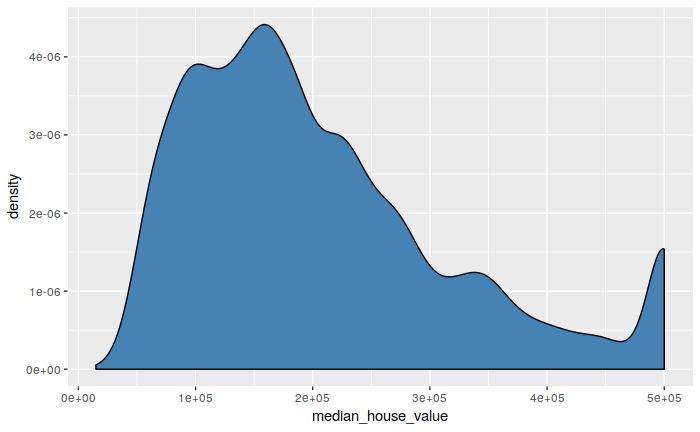

```r
ggplot(dfhousing) +
  geom_density(aes(x=median_house_value), fill="steel blue")
```

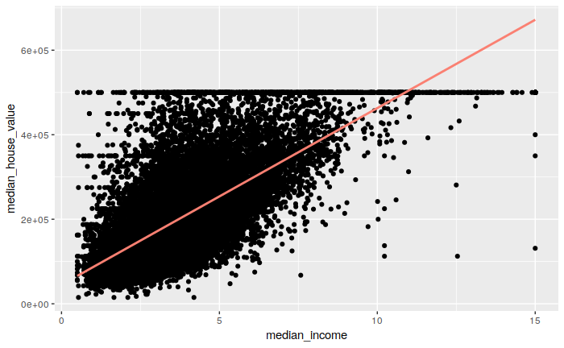

```r
ggplot(dfhousing) +
  geom_point(aes(x = median_income, y = median_house_value)) +
  stat_smooth(aes(x = median_income, y = median_house_value), method = "lm", color = "salmon", se = F)
```

En base a este gráfico podemos observar que en promedio las casas no superan los U$S 500.000 y esto podría afectar al modelo porque hay un límite claramente marcado, pero desconocemos si ese límite fue puesto a propósito por lo que los eliminaremos para nuestro análisis.

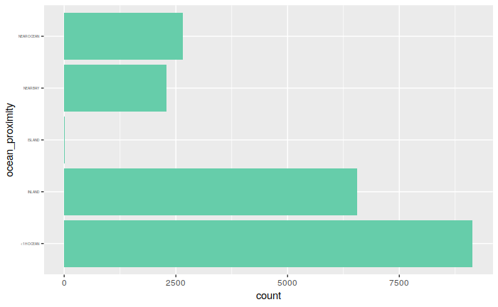

```r
ggplot(dfhousing) +
  geom_bar(aes(x=ocean_proximity), fill="mediumaquamarine")+
  coord_flip() +
  theme(axis.text.y=element_text(size=rel(0.4)))
```

## Limpieza de datos

Se eliminan los NA de **total_bedrooms**

```r
dfhousing$total_bedrooms[is.na(dfhousing$total_bedrooms)]= median(dfhousing$total_bedrooms, na.rm=TRUE)
```

Filtramos los datos para eliminar los valores máximos de median_house_value para eliminar las casa que tienen un precio mayor o igual a U$s 500.000

```r
dfhousing <- dfhousing[dfhousing$median_house_value < 500000,]
```

Para corregir los altos valores máximos se crean dos nuevas columnas: *mean_bedrooms: El cuociente entre habitaciones por hogares.* mean_rooms: El cuociente entre ambientes por hogares. Posteriormente eliminamos las columnas total_bedrooms y total_rooms

```r
dfhousing$mean_bedrooms = dfhousing$total_bedrooms / dfhousing$households
```

[output not shown]

```r
#Eliminamos las columnas total_bedrooms y total_rooms para usar el nuevo índice
drops = c('total_bedrooms', 'total_rooms', 'longitude', 'latitude')
dfhousing = dfhousing[ , !(names(dfhousing) %in% drops) ]
```

Controlamos la nueva estructura de la tabla

```r
head(dfhousing)
```

|  | housing_median_age | population | households | median_income | median_house_value | ocean_proximity | mean_bedrooms | mean_rooms |
| --- | --- | --- | --- | --- | --- | --- | --- | --- |
| 1 | 41 | 322 | 126 | 8.3252 | 452600 | NEAR BAY | 1.0238095 | 6.984127 |
| 2 | 21 | 2401 | 1138 | 8.3014 | 358500 | NEAR BAY | 0.9718805 | 6.238137 |
| 3 | 52 | 496 | 177 | 7.2574 | 352100 | NEAR BAY | 1.0734463 | 8.288136 |
| 4 | 52 | 558 | 219 | 5.6431 | 341300 | NEAR BAY | 1.0730594 | 5.817352 |
| 5 | 52 | 565 | 259 | 3.8462 | 342200 | NEAR BAY | 1.0810811 | 6.281853 |
| 6 | 52 | 413 | 193 | 4.0368 | 269700 | NEAR BAY | 1.1036269 | 4.761658 |

```r
#Creamos un nuevo dataframe auxiliar sin ocean_proximity que es categórico, ni median_house_value
#que el dato que se intentará predecir. Luego se escalan los valores para trabajarlos con gráficos más legibles.
drops = c('ocean_proximity','median_house_value', 'latitude', 'longitude')
dfhousing_aux =  dfhousing[ , !(names(dfhousing) %in% drops)]
dfscaledhousing_aux = scale(dfhousing_aux)
```

```r
#Creamos un nuevo dataframe que contenga solo la proximidad al mar. Luego limpiamos el resto de las columnas
dropsCategories = c('ocean_proximity', 'median_house_value')
dfcat_aux =  dfhousing[ , (names(dfhousing) %in% dropsCategories)]
```

```r
#Combinamos las dataframes y generamos un nuevo que contenga la combinación con los datos escalados y las categorías.
dfhousing_clean = cbind(DataSet1=dfcat_aux, DataSet2=dfscaledhousing_aux, median_house_value=dfhousing$median_house_value)

dropClean = c('DataSet1.median_house_value')
dfhousing_clean =  dfhousing_clean[ , !(names(dfhousing_clean) %in% dropClean)]

newNames = c('ocean_proximity', 'housing_median_age', 'population', 'households', 'median_income', 'mean_bedrooms', 'mean_rooms', 'median_house_value')
colnames(dfhousing_clean) <- newNames
```

## Visualización de correlaciones

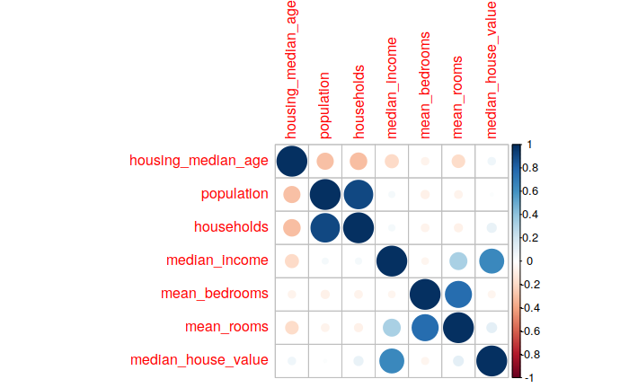

```r
dfhousing_clean %>%
    select_if(is.numeric) %>%
    cor() %>%
    corrplot()
```

En base al gráfico de correlación se puede determinó que existe una fuerte relación entre la cantidad de la población y la cantidad de hogares. También que el precio de las casas está relacionado con el ingreso medio por lo que pueden haber barrios más caros.

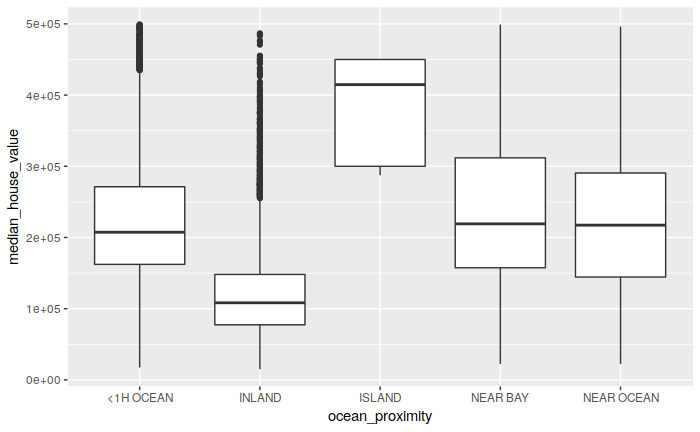

```r
ggplot(dfhousing_clean) +
    geom_boxplot(aes(x=ocean_proximity, y=median_house_value))
```

En este gráfico podemos observar que la proximidad al mar y al océano impactan fuertemente en el precio de la propiedad.

# Construcción de modelos

## Creación de datos de entrenamiento y pruebas

Creamos dos datasets: Uno de entrenamiento y otro de pruebas utilizando la proporción 80 para entrenamiento y 20 para test.

```r
set.seed(77222)
seleccion <- runif(dim(dfhousing_clean)[1])

dftrain <- select(dfhousing_clean, population, median_house_value, median_income, mean_rooms, households, ocean_proximity, housing_median_age, mean_bedrooms)[seleccion < 0.8, ]
dftest <- select(dfhousing_clean, population, median_house_value, median_income, mean_rooms, households, ocean_proximity, housing_median_age, mean_bedrooms)[seleccion >= 0.8, ]
```

## Modelo 1.

El primer modelo utiliza los predictores: **median_income**, **mean_rooms** y **population** para intentar predecir el valor de las propiedades plasmados en **median_house_value**.

```r
lineModel <- lm( median_house_value~median_income+mean_rooms+population, data=dftrain)
summary(lineModel)
```

```
Call:
lm(formula = median_house_value ~ median_income + mean_rooms +
    population, data = dftrain)

Residuals:
    Min      1Q  Median      3Q     Max
-535377  -50017  -13915   36035  503241

Coefficients:
              Estimate Std. Error t value Pr(>|t|)
(Intercept)   192561.6      584.3 329.577  < 2e-16 ***
median_income  67281.2      618.4 108.796  < 2e-16 ***
mean_rooms    -10406.6      607.8 -17.121  < 2e-16 ***
population     -2557.8      581.1  -4.402 1.08e-05 ***
---
Signif. codes:  0 ‘***’ 0.001 ‘**’ 0.01 ‘*’ 0.05 ‘.’ 0.1 ‘ ’ 1

Residual standard error: 73360 on 15763 degrees of freedom
Multiple R-squared:  0.4363,    Adjusted R-squared:  0.4362
F-statistic:  4066 on 3 and 15763 DF,  p-value: < 2.2e-16
```

```r
vif(lineModel)
```

```
median_income    mean_rooms    population
     1.117881      1.121178      1.009090
```

Los factores de inflación de la varianza tomados tienen valores aceptables ya que son menores a 10.

```r
predModel <- predict(lineModel, newdata = dftrain)
summary(predModel)
```

```
   Min. 1st Qu.  Median    Mean 3rd Qu.    Max.
-340741  145121  183300  192263  229394  666677
```

```r
mean(predModel)
```

```
[1] 192263.2
```

```r
sd(predModel)
```

```
[1] 64532.45
```

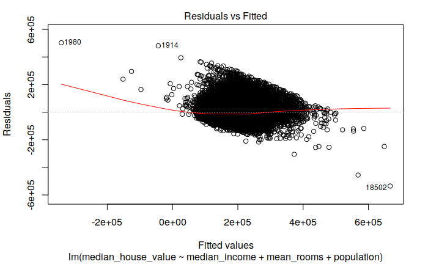

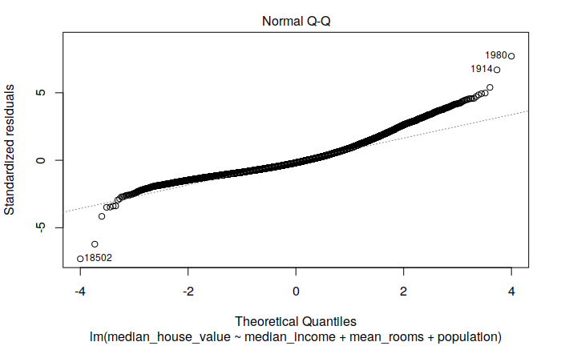

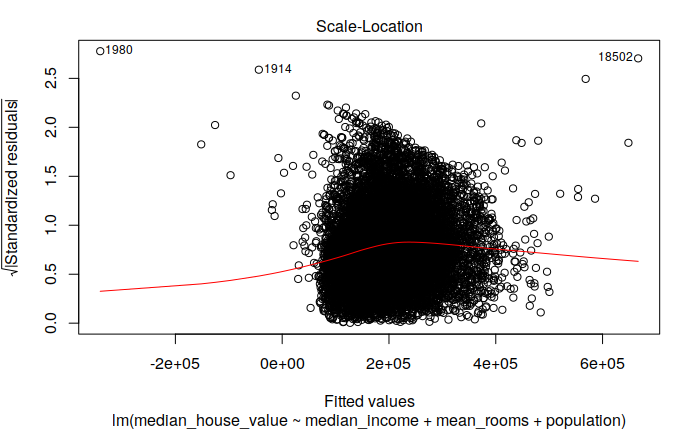

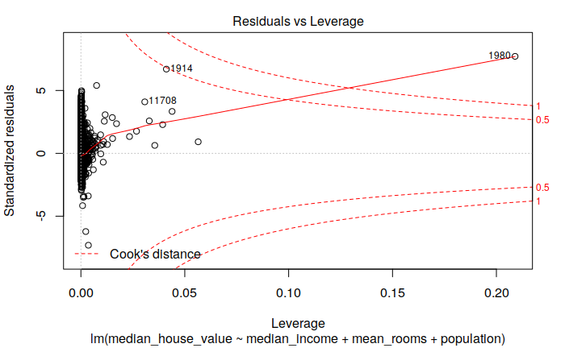

```r
plot(lineModel)
```

## Modelo 2.

El segundo modelo utiliza los predictores: **median_income**, **mean_rooms**, **population** y **housing_median_age** para intentar predecir el valor de las propiedades plasmados en **median_house_value**.

```r
lineModel2 <- lm( median_house_value~median_income+mean_rooms+population+housing_median_age, data=dftrain)
summary(lineModel2)
```

```
Call:
lm(formula = median_house_value ~ median_income + mean_rooms +
    population + housing_median_age, data = dftrain)

Residuals:
    Min      1Q  Median      3Q     Max
-586838  -48977  -12660   35151  432713

Coefficients:
                   Estimate Std. Error t value Pr(>|t|)
(Intercept)        192466.4      567.2  339.30  < 2e-16 ***
median_income       69892.3      606.3  115.28  < 2e-16 ***
mean_rooms          -7618.7      596.9  -12.76  < 2e-16 ***
population           3044.8      592.4    5.14 2.78e-07 ***
housing_median_age  18921.0      610.2   31.01  < 2e-16 ***
---
Signif. codes:  0 ‘***’ 0.001 ‘**’ 0.01 ‘*’ 0.05 ‘.’ 0.1 ‘ ’ 1

Residual standard error: 71230 on 15762 degrees of freedom
Multiple R-squared:  0.4687,    Adjusted R-squared:  0.4685
F-statistic:  3476 on 4 and 15762 DF,  p-value: < 2.2e-16
```

```r
vif(lineModel2)
```

```
     median_income         mean_rooms         population housing_median_age
          1.139868           1.147205           1.112583           1.163611
```

Los factores de inflación de la varianza tomados tienen valores aceptables ya que son menores a 10.

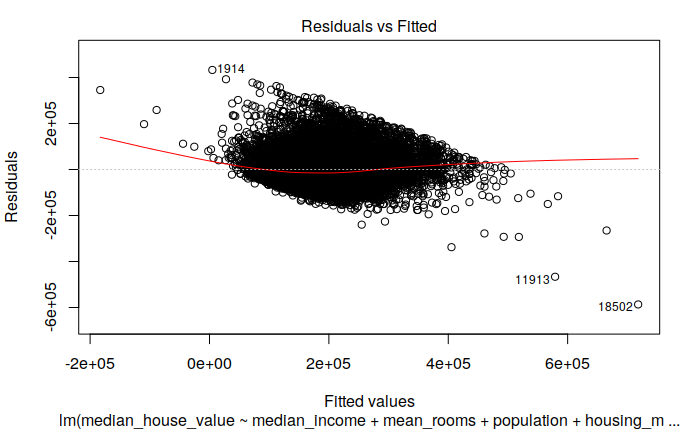

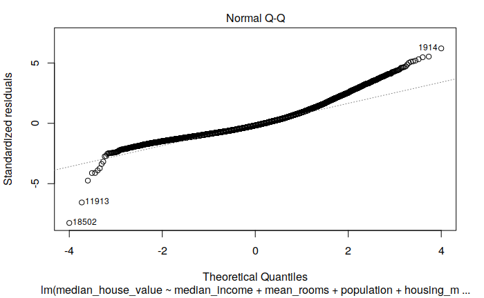

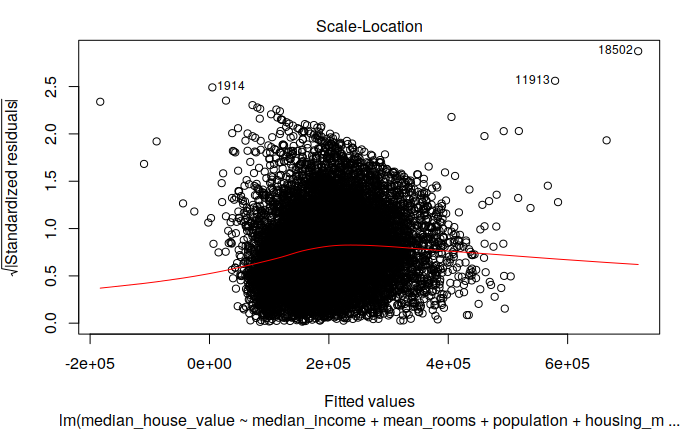

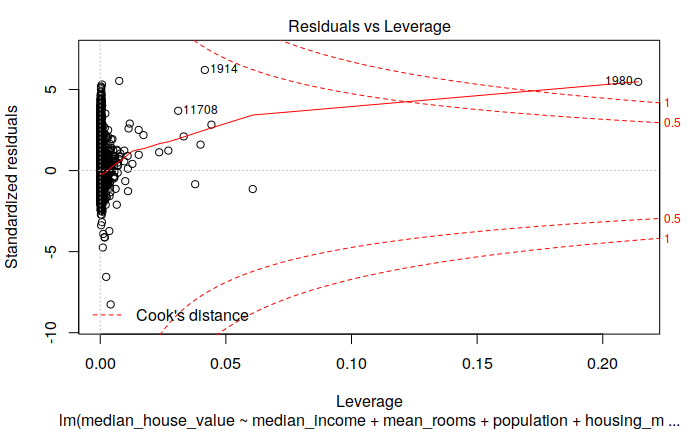

```r
plot(lineModel2)
```

```r
predModel2 <- predict(lineModel2, newdata = dftrain)
summary(predModel2)
```

```
   Min. 1st Qu.  Median    Mean 3rd Qu.    Max.
-183025  144131  183991  192263  232235  718138
```

```r
mean(predModel2)
```

```
[1] 192263.2
```

```r
sd(predModel2)
```

```
[1] 66886.83
```